# TidyTuesday : Tour de France Data

[figure not shown]

If you know me, you know I’m a huge cycling fan. So when I saw this TidyTuesday dataset come up, I was sold. This will walk you through how I went about analysing and plotting the dataset as part of the #TidyTuesday challenge. I’m trying to write more tutorial-style content, and figured this would be a good intro to the basics of data visualisation, for those who are used to using the tidyverse `dplyr`.

## Data Exploration

Let’s start at the beginning, and load our libraries, get the data in, and see what it looks like.

```r
library(tidyverse)
library(lubridate)
library(viridis)

tdf_stage_wins <- read_csv("data/tdf_stage_wins.csv")
tdf_stages <- read_csv("data/tdf_stages.csv")
tdf_winners <- read_csv("data/tdf_winners.csv")

# # I saved the files and loaded them in to save time, you can download them all using the following code though direct from the repo
# tdf <- tidytuesdayR::tt_load('2020-04-07')
# tdf_stage_wins <- tdf$stage_data %>% clean_names()
# tdf_stages <- tdf$tdf_stages %>% clean_names()
# tdf_winners <- tdf$tdf_winners %>% clean_names() %>% mutate(year = lubridate::year(start_date))
# rm(tdf)
```

So, we have three datasets: `tdf_stage_wins`, `tdf_stages`, and `tdf_winners`.

```r
glimpse(tdf_winners)
```

```
## Rows: 106
## Columns: 20
## $ edition       <dbl> 1, 2, 3, 4, 5, 6, 7, 8, 9, 10, 11, 12, 13, 14, 15, 16, 1…
## $ start_date    <date> 1903-07-01, 1904-07-02, 1905-07-09, 1906-07-04, 1907-07…
## $ winner_name   <chr> "Maurice Garin", "Henri Cornet", "Louis Trousselier", "R…
## $ winner_team   <chr> "La Française", "Conte", "Peugeot–Wolber", "Peugeot–Wolb…
## $ distance      <dbl> 2428, 2428, 2994, 4637, 4488, 4497, 4498, 4734, 5343, 52…
## $ time_overall  <dbl> 94.55389, 96.09861, NA, NA, NA, NA, NA, NA, NA, NA, 197.…
## $ time_margin   <dbl> 2.98916667, 2.27055556, NA, NA, NA, NA, NA, NA, NA, NA, …
## $ stage_wins    <dbl> 3, 1, 5, 5, 2, 5, 6, 4, 2, 3, 1, 1, 1, 4, 2, 0, 3, 4, 4,…
## $ stages_led    <dbl> 6, 3, 10, 12, 5, 13, 13, 3, 13, 13, 8, 15, 2, 14, 14, 3,…
## $ height        <dbl> 1.62, NA, NA, NA, NA, NA, 1.78, NA, NA, NA, NA, NA, NA, …
## $ weight        <dbl> 60, NA, NA, NA, NA, NA, 88, NA, NA, NA, NA, NA, NA, NA, …
## $ age           <dbl> 32, 19, 24, 27, 24, 25, 22, 22, 26, 23, 23, 24, 33, 30, …
## $ born          <date> 1871-03-03, 1884-08-04, 1881-06-29, 1879-06-05, 1882-10…
## $ died          <date> 1957-02-19, 1941-03-18, 1939-04-24, 1907-01-25, 1917-12…
## $ full_name     <chr> NA, NA, NA, NA, "Lucien Georges Mazan", "Lucien Georges …
## $ nickname      <chr> "The Little Chimney-sweep", "Le rigolo (The joker)", "Le…
## $ birth_town    <chr> "Arvier", "Desvres", "Paris", "Moret-sur-Loing", "Plessé…
## $ birth_country <chr> "Italy", "France", "France", "France", "France", "France…
## $ nationality   <chr> " France", " France", " France", " France", " France", "…
## $ year          <dbl> 1903, 1904, 1905, 1906, 1907, 1908, 1909, 1910, 1911, 19…
```

The `tdf_winners` isn’t very big (has `106` rows, and `20` columns), and has a mix of numeric, text, and date info to work with as well.

```r
glimpse(tdf_stages)
```

```
## Rows: 2,236
## Columns: 9
## $ stage          <chr> "1", "2", "3", "4", "5", "6", "7", "8", "9", "10", "11"…
## $ date           <date> 2017-07-01, 2017-07-02, 2017-07-03, 2017-07-04, 2017-0…
## $ distance       <dbl> 14.0, 203.5, 212.5, 207.5, 160.5, 216.0, 213.5, 187.5, …
## $ origin         <chr> "Düsseldorf", "Düsseldorf", "Verviers", "Mondorf-les-Ba…
## $ destination    <chr> "Düsseldorf", "Liège", "Longwy", "Vittel", "La Planche …
## $ type           <chr> "individual time trial", "flat stage", "medium mountain…
## $ winner         <chr> "Geraint Thomas", "Marcel Kittel", "Peter Sagan", "Arna…
## $ winner_country <chr> "GBR", "GER", "SVK", "FRA", "ITA", "GER", "GER", "FRA",…
## $ year           <dbl> 2017, 2017, 2017, 2017, 2017, 2017, 2017, 2017, 2017, 2…
```

The `tdf_stages` dataset contains basic info about each stage: when it occurred, where it started, where it ended, what type of stage it was, and who won it.

```r
glimpse(tdf_stage_wins)
```

```
## Rows: 255,752
## Columns: 11
## $ edition          <dbl> 1, 1, 1, 1, 1, 1, 1, 1, 1, 1, 1, 1, 1, 1, 1, 1, 1, 1,…
## $ year             <dbl> 1903, 1903, 1903, 1903, 1903, 1903, 1903, 1903, 1903,…
## $ stage_results_id <chr> "stage-1", "stage-1", "stage-1", "stage-1", "stage-1"…
## $ rank             <chr> "1", "2", "3", "4", "5", "6", "7", "8", "9", "10", "1…
## $ time             <chr> "13S", "55S", "59S", "48S", "53S", "53S", "55S", "47S…
## $ rider            <chr> "Garin Maurice", "Pagie Émile", "Georget Léon", "Auge…
## $ age              <dbl> 32, 32, 23, 20, 36, 37, 25, 33, NA, 22, 26, 28, 21, 2…
## $ team             <lgl> NA, NA, NA, NA, NA, NA, NA, NA, NA, NA, NA, NA, NA, N…
## $ points           <dbl> 100, 70, 50, 40, 32, 26, 22, 18, 14, 10, 8, 6, 4, 2, …
## $ elapsed          <chr> "13S", "8S", "12S", "1S", "6S", "6S", "8S", "0S", "28…
## $ bib_number       <lgl> NA, NA, NA, NA, NA, NA, NA, NA, NA, NA, NA, NA, NA, N…
```

The `tdf_stage_wins` contains more detailed information about each year’s race: who won each stage, what time the rider achieved, and how many points they gained.

# TDF Winners Dataset

Let’s start at the beginning and look at the `tdf_winners` dataset. One thing that we can do first is see how many unique riders and teams we have.

```r
tdf_winners %>%
  summarise(winner_count = n_distinct(winner_name),
            team_count = n_distinct(winner_team))
```

| winner_count | team_count |
| --- | --- |
| 63 | 48 |

So, only 63 cyclists, but 106 editions. So some cyclists have won multiple. And only 48 different teams. Interesting.

So let’s start there, and have a look at the winner and team demographics first.

Let’s start with the biggest question: who are the “best” riders? I.e. who are those that have won more than one Tour.

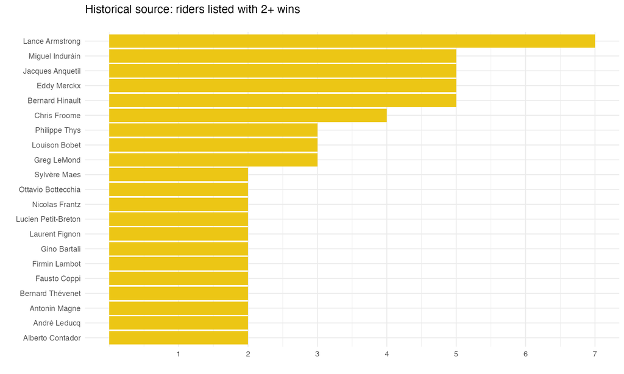

```r
winners_plot <- tdf_winners %>%
  group_by(winner_name) %>%
  summarise(count = n()) %>%
  arrange(desc(count)) %>%
  filter(count >= 2) %>%
  ggplot() +
  aes(x = reorder(winner_name, count), y = count) +
  geom_col(fill = "#ECC615") +
  coord_flip() +
  ylab(" ") + xlab(" ") + ggtitle("Historical source: riders listed with 2+ wins\n") +
  theme(legend.position = "none",
        panel.spacing.x = unit(2, "lines"),
        strip.text = element_blank(),
        plot.margin = unit(c(0.5, 0.5, 0, 0.5), "cm"), #top, right, bottom, left
        panel.border = element_blank()
        ) +
  scale_y_continuous(breaks = c(1,2,3,4,5,6,7)) +
  theme_minimal() +
  theme(text=element_text(family="sans"))

winners_plot
```

This source retains annulled results, including Lance Armstrong’s. Treat this as an exploration of the historical source, not the official current winners list.

Next, what about the top teams these people raced for?

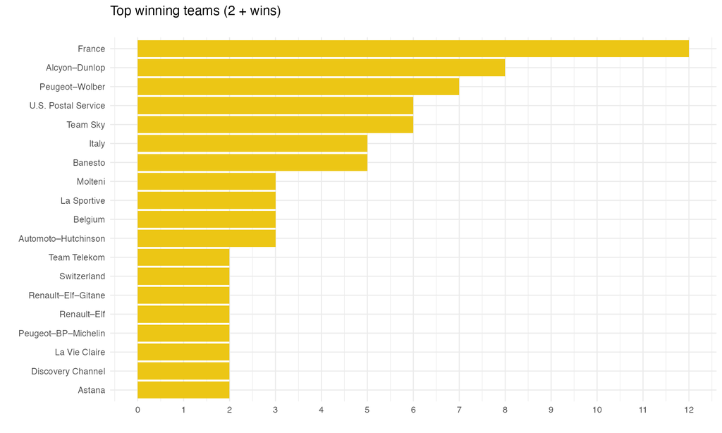

```r
teams_plot <- tdf_winners %>%
  group_by(winner_team) %>%
  summarise(count = n()) %>%
  arrange(desc(count)) %>%
  filter(count >= 2) %>%
    ggplot() +
  aes(x = reorder(winner_team, count), y = count) +
  geom_col(fill = "#ECC615") +
  coord_flip() +
  scale_y_continuous(breaks = c(0:13)) +
  theme(legend.position = "none",
        panel.spacing.x = unit(2, "lines"),
        strip.text = element_blank(),
        plot.margin = unit(c(0.5, 0.5, 0, 0.5), "cm"), #top, right, bottom, left
        panel.border = element_blank()
        ) +
  theme_minimal() +
  theme(text=element_text(family="sans")) +
  ylab(" ") + xlab(" ") + ggtitle("Top winning teams (2 + wins) \n")

teams_plot
```

Not really surprising that Team France has the most. We can check and see if this is consistent with the winning nationalities of the riders next.

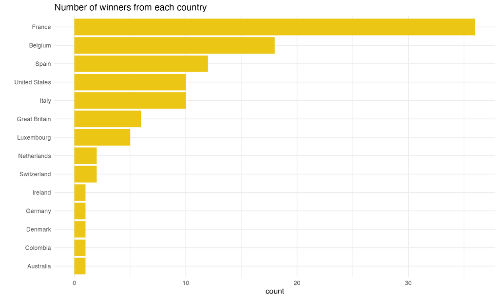

```r
countries_plot <- tdf_winners %>%
  group_by(nationality) %>%
  summarise(count = n()) %>%
  arrange(desc(count)) %>%
  ggplot(aes(x = reorder(nationality,count), y = count)) +
  geom_col(fill = "#ECC615") +
  coord_flip() +
  xlab(" ") + ggtitle("Number of winners from each country")  +
  theme(legend.position = "none",
        panel.spacing.x = unit(2, "lines"),
        strip.text = element_blank(),
        plot.margin = unit(c(0.5, 0.5, 0, 0.5), "cm"), #top, right, bottom, left
        panel.border = element_blank()
        ) +
  theme_minimal() +
  theme(text=element_text(family="sans"))

countries_plot
```

Ok yeah… still France. Checks out!

Finally, maybe we just check the overall rider demographics.

```r
tdf_winners %>%
  summarise(median_age = median(age, na.rm = TRUE),
            median_height = median(height, na.rm = TRUE),
            median_weight = median(weight, na.rm = TRUE))
```

| median_age | median_height | median_weight |
| --- | --- | --- |
| 28 | 1.77 | 69 |

A group of young, average height, skinny cyclists! Again, checks out. That seems like all the info we have about the riders and teams, so we can move on to the race itself.

# Race Info

Let’s start with the distances of the race. It’s no secret that the race has changed as time has gone on. So we can investigate the races. Let’s look at how race distances have changed first.

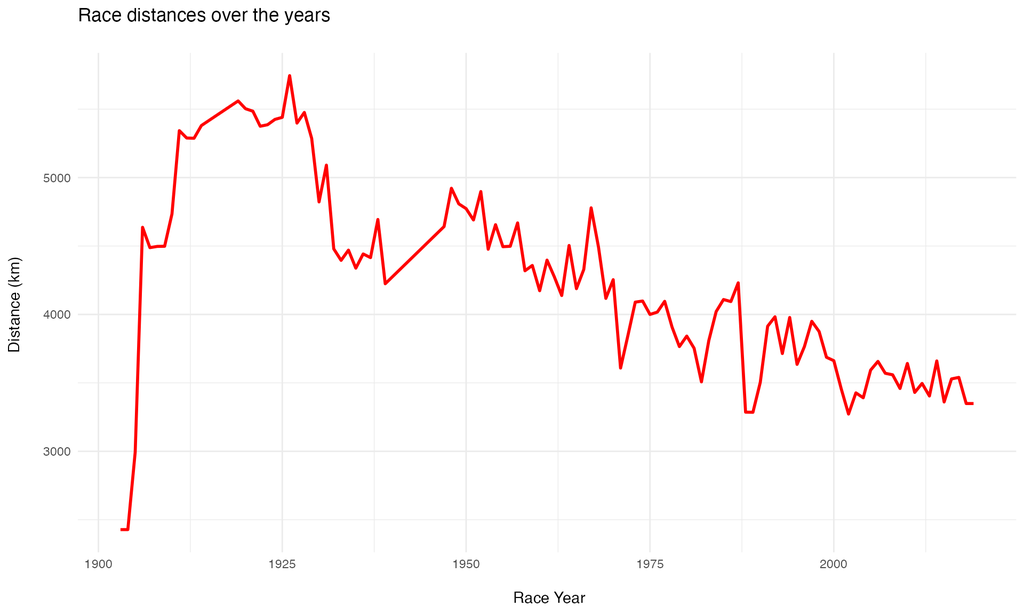

```r
distances_plot <- tdf_winners %>%
  ggplot(aes(x = year, y = distance)) +
  geom_line(color = "red", linewidth = 1) +
  xlab("\n Race Year") + ylab("Distance (km) \n")  +
  ggtitle("Race distances over the years \n") +
  theme(legend.position = "none",
        panel.spacing.x = unit(2, "lines"),
        strip.text = element_blank(),
        plot.margin = unit(c(1, 1, 1, 1), "cm"), #top, right, bottom, left
        panel.border = element_blank()
        ) +
  theme_minimal() +
  theme(text=element_text(family="sans"))


distances_plot
```

What about how the riders times have changed over the years?

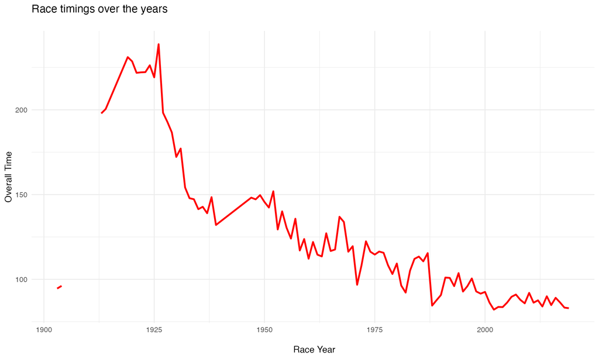

```r
timings_plot <- tdf_winners %>%
  ggplot(aes(year, time_overall)) +
  geom_line(color = "red", linewidth = 1) +
  xlab("\n Race Year") + ylab("Overall Time")  +
  ggtitle("Race timings over the years \n") +
  theme(legend.position = "none",
        panel.spacing.x = unit(2, "lines"),
        strip.text = element_blank(),
        plot.margin = unit(c(0.5, 0.5, 0, 0.5), "cm"), #top, right, bottom, left
        panel.border = element_blank()
        ) +
  theme_minimal() +
  theme(text=element_text(family="sans"))

timings_plot
```

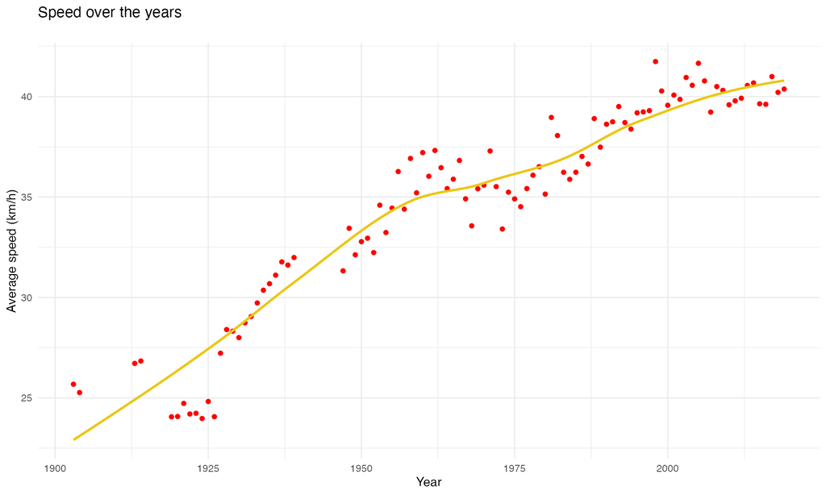

```r
speed_plot <- tdf_winners %>%
  mutate(speed = distance / time_overall) %>%
  ggplot() +
  aes(x = year, y = speed) +
  geom_point(color = "Red") +
  geom_smooth(color = "#ECC615", se = FALSE)  +
  xlab("Year") + ylab("Average speed (km/h)") +
  ggtitle("Speed over the years \n") +
  theme(legend.position = "none",
        panel.spacing.x = unit(2, "lines"),
        strip.text = element_blank(),
        plot.margin = unit(c(0.5, 0.5, 0, 0.5), "cm"), #top, right, bottom, left
        panel.border = element_blank()
        ) +
  theme_minimal() +
  theme(text=element_text(family="sans"))

speed_plot
```

So this confirms what we think - speed has gone up over the years.

We can just finish this bit up by looking at the names of the riders that have the top/bottom distances, timings, and speeds.

```r
tdf_winners %>%
  filter(distance == max(distance) | distance == min(distance)) %>%
  select(year, distance, winner_name)
```

| year | distance | winner_name |
| --- | --- | --- |
| 1903 | 2428 | Maurice Garin |
| 1904 | 2428 | Henri Cornet |
| 1926 | 5745 | Lucien Buysse |

```r
tdf_winners %>%
  drop_na(time_overall) %>%
  filter(time_overall == min(time_overall) | time_overall == max(time_overall)) %>%
  select(winner_name, time_overall)
```

| winner_name | time_overall |
| --- | --- |
| Lucien Buysse | 238.74028 |
| Lance Armstrong | 82.08667 |

```r
tdf_winners %>%
  mutate(speed = distance / time_overall) %>%
  select(winner_name, speed) %>%
  drop_na(speed) %>%
  filter(speed == max(speed) | speed == min(speed))
```

| winner_name | speed |
| --- | --- |
| Ottavio Bottecchia | 23.97198 |
| Marco Pantani | 41.74322 |

# Stages

Next, we can start looking at more info about each stage. Let’s start with the `tdf_stages` data.

```r
# do some data cleaning
tdf_stages <- tdf_stages %>%
  mutate(year = lubridate::year(date),
         type = str_to_lower(type))
```

First, let’s look at who the top stage riders are. If you’re not used to the Tour, you should probably know that often the riders that win the overall Tour, don’t actually win many (if any) stages on it. Confusing, yes. But it gives us more to look at.

There is quite a lot of data here, so we will narrow it down by looking for riders that have won more than three stages.

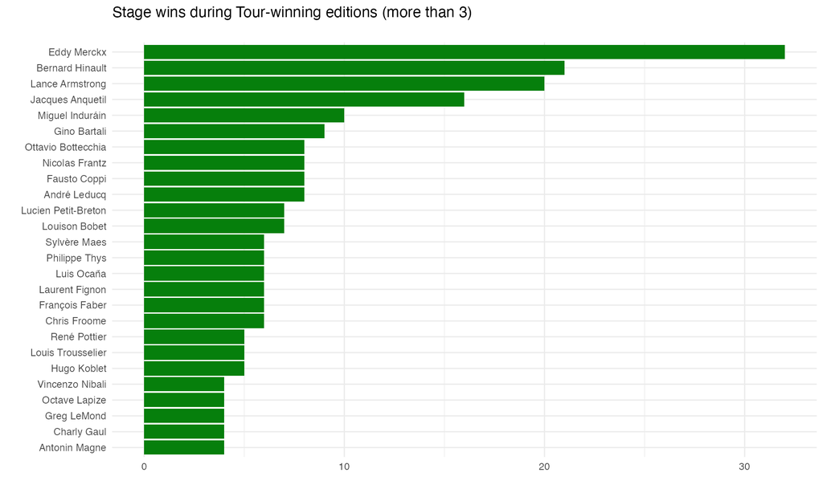

```r
stage_wins_plot <- tdf_winners %>%
  group_by(winner_name) %>%
  summarise(totals = sum(stage_wins)) %>%
  arrange(desc(totals)) %>%
  filter(totals > 3) %>%
    ggplot() +
    aes(reorder(winner_name,totals), totals) +
    geom_col(fill = "#067F0C") +
    coord_flip() +
  theme(legend.position = "none",
        panel.spacing.x = unit(2, "lines"),
        strip.text = element_blank(),
        plot.margin = unit(c(0.5, 0.5, 0, 0.5), "cm"), #top, right, bottom, left
        panel.border = element_blank()
        ) +
  theme_minimal() +
  theme(text=element_text(family="sans")) +
  ylab(" ") + xlab(" ") + ggtitle("Stage wins during Tour-winning editions (more than 3)\n")

stage_wins_plot
```

Eddy Merckx is dwarfing everyone. He’s often hailed as the best rider of all time, so it makes sense to see him up there. You can also see the difference between stage win riders, and overall tour rides. Chris Froome for example has only won *one* less tour than Eddie, but he’s won far less stages.

The `stages_led` field records stages for which the eventual Tour winner led the general classification. It is not time spent leading a breakaway. Here we show riders with at least 14 stages led across their winning editions.

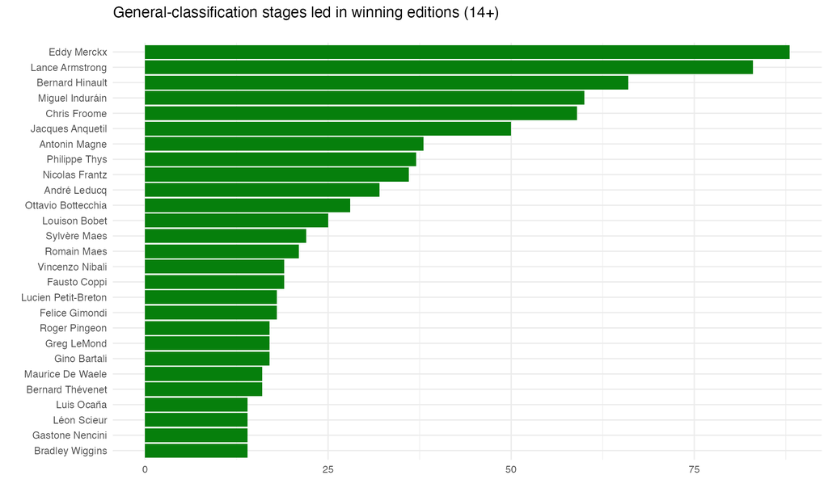

```r
stage_leads_plot <- tdf_winners %>%
  group_by(winner_name) %>%
  summarise(totals = sum(stages_led)) %>%
  arrange(desc(totals)) %>%
  filter(totals >= 14) %>%
  ggplot() +
  aes(reorder(winner_name,totals), totals) +
  geom_col(fill = "#067F0C") +
  coord_flip() +
  theme(legend.position = "none",
        panel.spacing.x = unit(2, "lines"),
        strip.text = element_blank(),
        plot.margin = unit(c(0.5, 0.5, 0, 0.5), "cm"), #top, right, bottom, left
        panel.border = element_blank()
        ) +
  theme_minimal() +
  theme(text=element_text(family="sans")) +
  ylab(" ") + xlab(" ") + ggtitle("General-classification stages led in winning editions (14+) \n")


stage_leads_plot
```

Again, Eddie reigns supreme.

Ok, onwards. Now we can look at different types of stages.

First things first, where do the stages start and end?

```r
origins <- tdf_stages %>%
  group_by(origin) %>%
  summarise(count = n()) %>%
  rename(name = origin) %>%
  mutate(place = "origin") %>%
  arrange(desc(count))

destinations <- tdf_stages %>%
  group_by(destination) %>%
  summarise(count = n()) %>%
  rename(name = destination) %>%
  mutate(place = "destination") %>%
  arrange(desc(count))

maps <- bind_rows(origins, destinations)
```

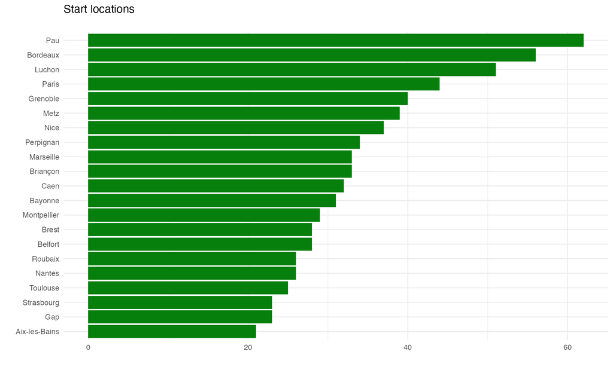

```r
start_plot <- maps %>%
  filter(place == "origin", count >20) %>%
ggplot() +
  aes(x = reorder(name, count), y = count) +
  geom_col(fill = "#067F0C")  +
  coord_flip() +
  xlab("") + ylab("") + ggtitle("Start locations \n") +
  theme(legend.position = "none",
        panel.spacing.x = unit(2, "lines"),
        strip.text = element_blank(),
        plot.margin = unit(c(0.5, 0.5, 0, 0.5), "cm"), #top, right, bottom, left
        panel.border = element_blank()
        ) +
  theme_minimal() +
  theme(text=element_text(family="sans"))

start_plot
```

Not hugely surprising either that the most common start points are the main places in France!

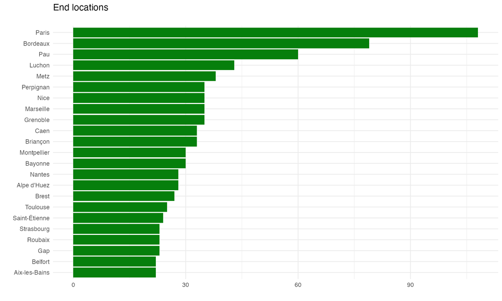

```r
end_plot <- maps %>%
  filter(place == "destination", count >20) %>%
ggplot() +
  aes(x = reorder(name, count), y = count) +
  geom_col(fill = "#067F0C")  +
  coord_flip() +
  xlab("") + ylab("") + ggtitle("End locations \n") +
  theme(legend.position = "none",
        panel.spacing.x = unit(2, "lines"),
        strip.text = element_blank(),
        plot.margin = unit(c(0.5, 0.5, 0, 0.5), "cm"), #top, right, bottom, left
        panel.border = element_blank()
        ) +
  theme_minimal() +
  theme(text=element_text(family="sans"))

end_plot
```

And the end locations aren’t that surprising either. But good to know anyway.

Right, onto the stage types we get.

```r
tdf_stages %>%
  distinct(type)
```

| type |
| --- |
| individual time trial |
| flat stage |
| medium mountain stage |
| high mountain stage |
| mountain time trial |
| team time trial |
| flat cobblestone stage |
| mountain stage |
| transition stage |
| plain stage |

[output cut: 6 more lines]

Some of these stages are pretty similar, so let’s combine them.

```r
tdf_stages <- tdf_stages %>%
  mutate(type = recode(type,
                       "stage with mountain(s)" = "mountain stage",
                       "stage with mountain" = "mountain stage",
                       "medium mountain stage" = "mountain stage",
                       "high mountain stage" = "mountain stage",
                       "plain stage with cobblestones" = "cobblestones", "flat cobblestone stage" = "cobblestones"
                       ))
```

Now we can plot them and have a look.

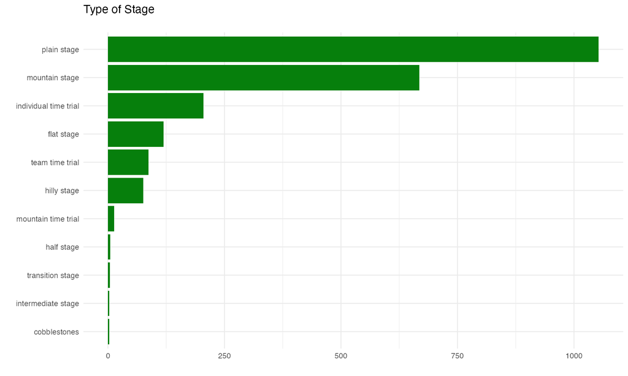

```r
stage_types_plot <- tdf_stages %>%
  group_by(type) %>%
  summarise(totals = n()) %>%
  arrange(desc(totals)) %>%
  ggplot(aes(x = reorder(type,totals), y = totals)) +
  geom_col(fill = "#067F0C") +
  coord_flip() +
  xlab("") + ylab("") + ggtitle("Type of Stage \n") +
  theme(legend.position = "none",
        panel.spacing.x = unit(2, "lines"),
        strip.text = element_blank(),
        plot.margin = unit(c(0.5, 0.5, 0, 0.5), "cm"), #top, right, bottom, left
        panel.border = element_blank()
        ) +
  theme_minimal() +
  theme(text=element_text(family="sans"))

stage_types_plot
```

Lots of standard stages (makes sense), and lots of mountains and time trials. Cobblestones are down the bottom (leave that to Paris Roubaix).

So what about the distance of each stage type?

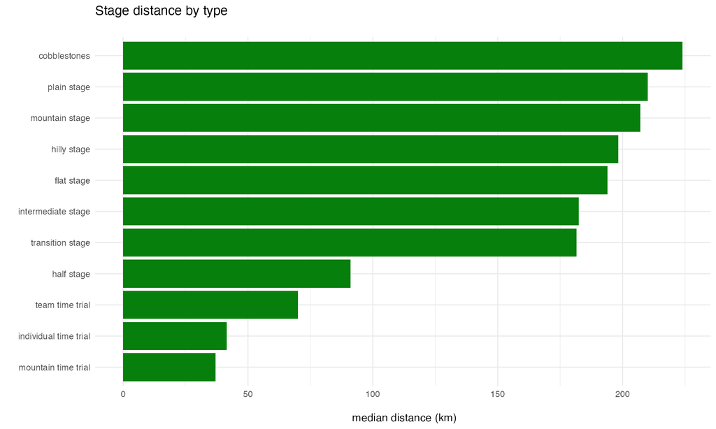

```r
stage_distance_plot <- tdf_stages %>%
  group_by(type) %>%
  summarise(median_distance = median(distance)) %>%
ggplot() +
  aes(x = reorder(type,median_distance), y = median_distance) +
  geom_col() +
  theme(axis.text.x = element_text(angle = 45, hjust=1)) +
  geom_col(fill = "#067F0C") +
  coord_flip() +
  xlab("") + ylab("\n median distance (km)") + ggtitle("Stage distance by type \n") +
  theme(legend.position = "none",
        panel.spacing.x = unit(2, "lines"),
        strip.text = element_blank(),
        plot.margin = unit(c(0.5, 0.5, 0, 0.5), "cm"), #top, right, bottom, left
        panel.border = element_blank()
        ) +
  theme_minimal() +
  theme(text=element_text(family="sans"))

stage_distance_plot
```

Well, we can see that even though there aren’t many cobble stages, they tend to be the longest when they do crop up! Time trials are the shortest, which does make sense, as they’re really meant to be intense short bursts.

Finally, we can look at which rider is the most diverse when it comes to different stage types.

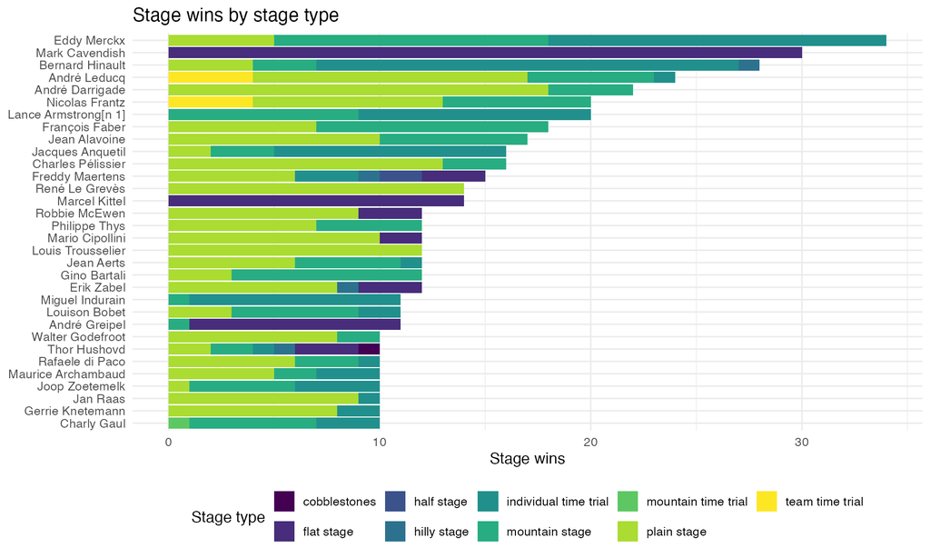

```r
stage_type_plot <- tdf_stages %>%
  count(winner, type, name = "wins") %>%
  group_by(winner) %>%
  mutate(total_wins = sum(wins)) %>%
  ungroup() %>%
  filter(total_wins >= 10) %>%
  ggplot(aes(x = reorder(winner, total_wins), y = wins, fill = type)) +
  geom_col() +
  coord_flip() +
  scale_fill_viridis_d(option = "viridis") +
  labs(title = "Stage wins by stage type", x = NULL, y = "Stage wins", fill = "Stage type") +
  theme_minimal(base_size = 12) +
  theme(text = element_text(family = "sans"), legend.position = "bottom")

stage_type_plot
```

And there we go, an analysis of the Tour de France data!